# Text Cleaning

### Introduction

In this page, I will introduce the methods I used to clean text data, as well as the reasons why I chose to use these methods due to the purpose of transparency. The code that I wrote to clean the data can be found here: [Data Cleaning Code](https://github.com/anly501/anly-501-project-yeyaxin1103/tree/main/codes/02-data-cleaning)

### Data 1: Twitter Search Responses (Tweets)

#### Language Used for Cleaning: Python

#### Data Source: [Twitter API](https://github.com/anly501/anly-501-project-yeyaxin1103/tree/main/data/00-raw-data/twitter_api_data)

This data was pulled from Twitter using Twitter API for keyword searching. Due to the reason that this project focuses on the fertility rate issue in East Asia, the response Tweets must contain either one or multiple of these following keyword: “China Fertility”, “Korea Fertility”, “Japan Fertility”, “Hong Kong Fertility”, “Mongolia Fertility”, and “Taiwan Fertility”. The goal was to attain 1000 Tweet responses, however, only 546 were returned. These Twitter response text data is transformed and stored in a JSON file that looks like this:

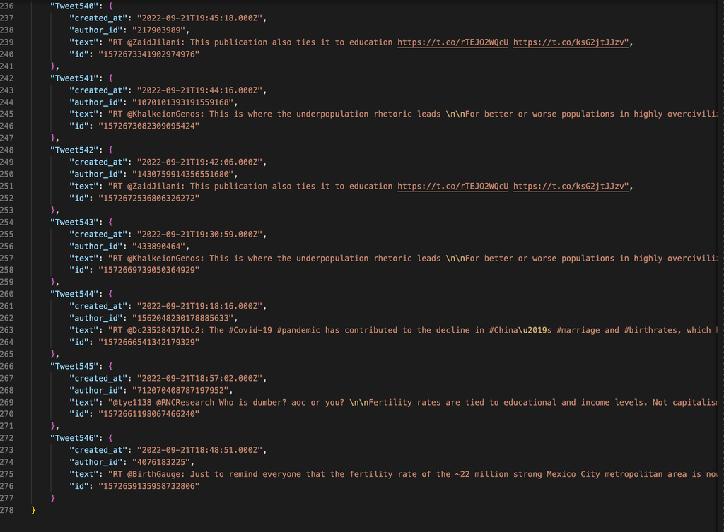

Step 1: Due to the fact that Twitter Search API searches against a sampling of recent Tweets published in the past 7 days, and user IDs as well as Tweet IDs are not needed and have very limited value for any future analysis. I decided to only keep the Tweet texts by deriving the text from each response Tweet and append them in a list to form a corpus of Tweets. The initial text corpus (raw) looks like this:

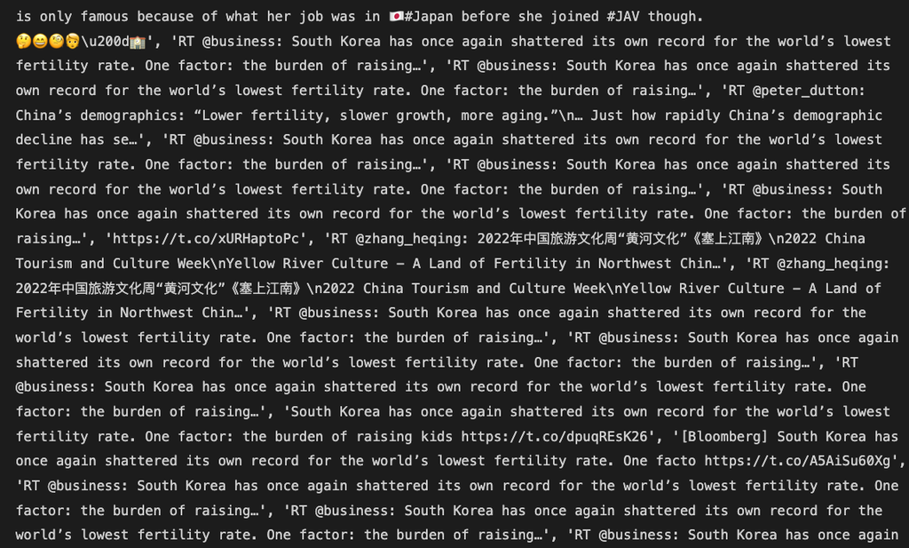

Step 2: By checking the vocabulary of the corpus using CountVectorizer, it is not hard to notice that the Tweet text corpus contains many non-English words, stop words, emojis, as well as non-character symbols, which would most likely hurdle the future analysis on these texts. Therefore, I decided to clean the text by removing hashtags, mentions, links, punctuation, and non-alphanumeric characters, and making all letters lowercase.

A snapshot of unique vocabulary in raw Tweet corpus:

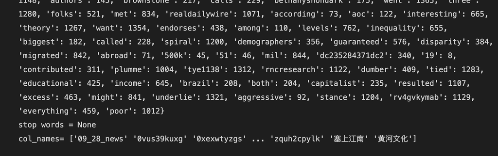

After removing hashtags, mentions, links, punctuation, and non-alphanumeric characters, the Tweet corpus now looks much cleaner and is ready for exploratory data analysis (EDA):

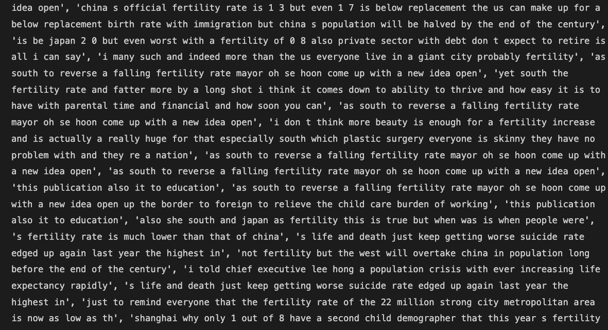

Finally, I wrote each text of Tweet in the clean corpus as a line and exported them for future analysis use. The output looks like this and can be found at here: [Clean Tweets File](https://github.com/anly501/anly-501-project-yeyaxin1103/tree/main/data/01-modified-data)

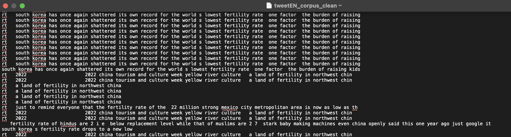